# Domestic Violence in Colombia: Findings from the DHS

Final Project

Sabina Rodriguez Velásquez

2023-08-08

# **Context**

Colombia has achieved important victories in the last two decades regarding the promotion of gender equality and women’ empowerment, although there are still significant gaps to reduce.

According to the [UN Women website](https://lac.unwomen.org/en/donde-estamos/colombia), Indigenous and Afro-Colombian women have been affected disproportionately by violence derived from the conflict; among 3,445 cases of murder in Indigenous and Afro-Colombian individuals, 65.5% were women. Additionally, in a UN country report measuring the violence against women during the COVID-19 confinement (pandemic), a survey conducted in Colombia of more than 1200 women between August and September demonstrated that violence against women was pervasive throughout the country, with **6 in 10 women (63%)** reporting that they or someone they know has experienced at least one form of violence.

The objective of this report is to descriptively analyse domestic violence against women in Colombia.

# **Data set Description**

The data set used in this report is a subset of the **Demographic and Health Surveys (DHS)**. The DHS are a series of standardized surveys conducted periodically in developing countries that collect data on various aspects of population, health, and nutrition. These surveys, which are funded by the United States Agency for International Development (USAID), are a gold-standard source of reliable public health data for many countries and international bodies.

The included subset is part of the *women’s recode dataset*. It contain individual-level data on women aged 15 to 49 in the surveyed households, from Colombia.

# **Sample Characteristics**

Out of 38718 surveyed individuals, a total of 38087 (98.4%) were included in the domestic violence module. From that subset of participants, 24890 women answered to some sort of question on domestic violence (emotional, physical, or sexual). Overall, out of the women who answered, a total of 10710 women (43%) reported experiencing some sort of domestic violence.

*It is important to take note of the important and relatively high amount of missing values (NA) in questions related to domestic violence.*

### Distribution of Domestic Violence in Women by Demographics

Based on the sample of women interviewed for the domestic violence module, the majority of women reported **NOT** experiencing domestic violence. A similar pattern can be seen through different demographics (e.g. age groups, urban vs. rural, wealth index, or education level).

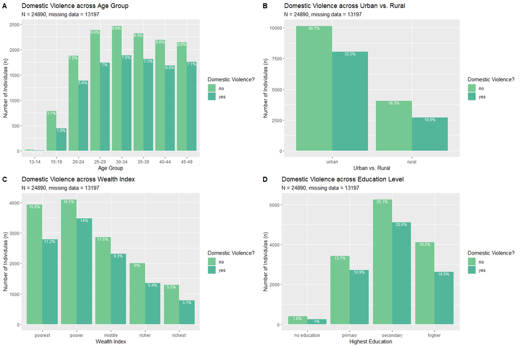

Figure 1. Domestic Violence Distribution across Various Demographic Variables

# **Domestic Violence: Descriptive Analysis**

### Types of Domestic Violence

To better understand the type of domestic violence experienced in women who **reported experiencing** some sort of domestic violence, Figure 2 breaks down the different types of domestic violence and their reported percentage.

*CAUTION: Note the amount of missing values*

Based on Figure 2, the three main types of domestic violence reported by Colombian women are emotional and physical violence, physical violence alone, and emotional violence alone.

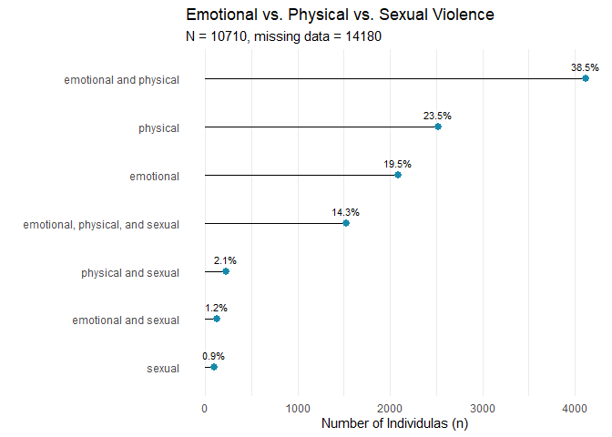

Figure 2. Domestic Violence Distribution by Type

### Perpetrators

When asking to identify the perpetrator (for physical violence ONLY), fewer women answered. Overall, 90.9% of respondents did not identify any of the given options as a perpetrator (mother, children, relative, current boyfriend, or former boyfriend). For the respondents that did identify someone, 6.7% identified family members (mother, children, other relative), 1.9% identified partners (current boyfriend, former boyfriend), and only 0.5% identified **both** family member **and** partner.

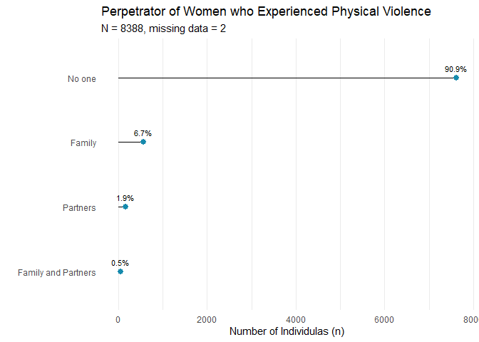

Figure 3. Reported Perpetrators

# **Conclusion**

Overall, 43% of women surveyed reported some sort of domestic violence. When looking at the distribution of domestic violence by demographics, no specific factor or pattern was identified.

A high number of missing values were identified to questions related to domestic violence. This might be due to the fact that some participants did not want to answer those sensitive questions. Due to the high number of missing values, the results above have to be carefully analysed and interpreted.